# C.R.O.W.

Observed 24 PM2.5 Average (Lafayette)

11.2

[interactive chart not shown]

Yesterday's Observed 12p-8p Ozone Average (Carus)

NA

```
No Ozone data available for this selection.
```

[interactive chart not shown]

Today (Avg)

53 F

Noon Today to Noon Tomorrow

52 F

This Evening (6p-12a)

53 F

Tomorrow (12a-12a)

50 F

[interactive chart not shown]

Today

1410 feet

Noon Today to Noon Tomorrow

1417 feet

This Evening (6p-12a)

1174 feet

Tomorrow (12a-12a)

1651 feet

[interactive chart not shown]

Today

3 mph

Noon Today to Noon Tomorrow

3 mph

This Evening (6p-12a)

4 mph

Tomorrow (12a-12a)

1 mph

[interactive chart not shown]

Today

8 knots

Noon Today to Noon Tomorrow

8 knots

This Evening (6p-12p)

10 knots

Tomorrow (12a-12am)

5 knots

[interactive chart not shown]

Today

1 %

Noon today to Noon Tomorrow

1 %

This Evening (6p-12a)

1 %

Tomorrow (12a-12a)

0 %

[interactive chart not shown]

Today

77 %

Noon today to Noon Tomorrow

77 %

This Evening (6p-12a)

70 %

Tomorrow (12a-12a)

80 %

[interactive chart not shown]

Today

36 %

Noon today to Noon Tomorrow

47 %

This Evening (6p-12a)

34 %

Tomorrow (12a-12a)

40 %

Forecast

Forecast

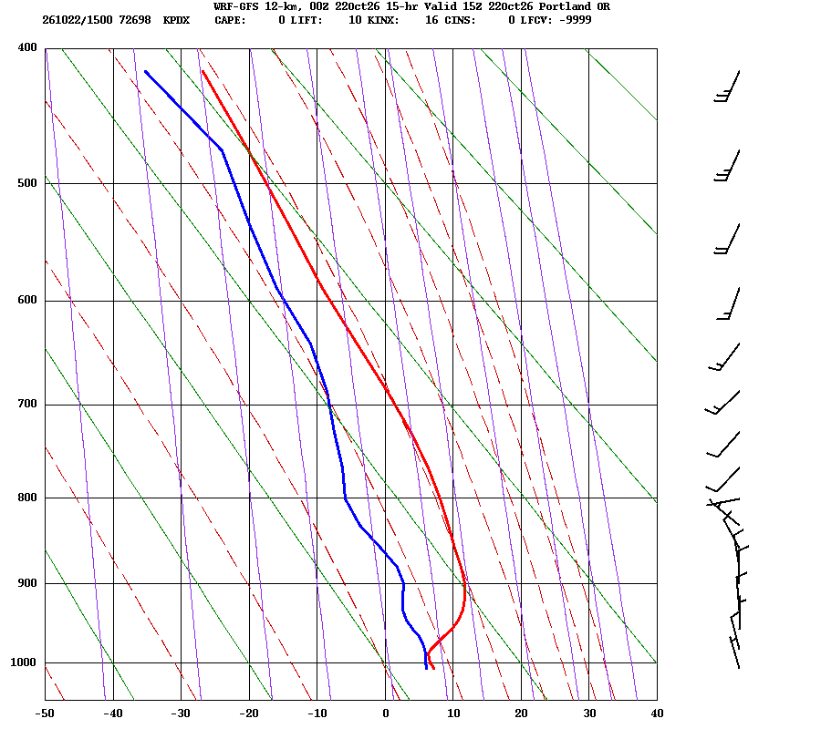

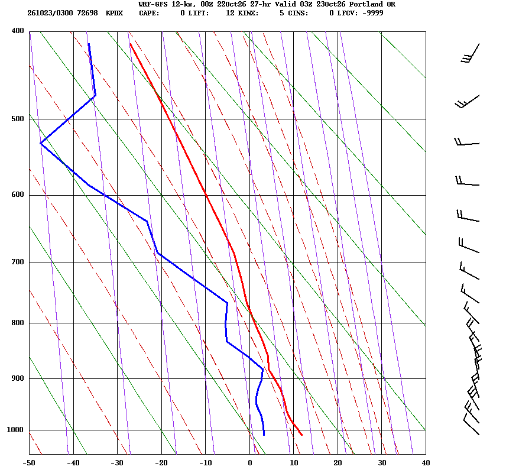

```
458
FXUS66 KPQR 221108
AFDPQR

Area Forecast Discussion
National Weather Service Portland OR
408 AM PDT Thu Oct 22 2026

.SYNOPSIS...Dry and cooling temperatures will occur through the
work week before weak storm systems return chances for
beneficial rain over the weekend and early next week.

&&

.DISCUSSION...Now through Wednesday...A weak shortwave will move
over the region today, sending a decaying cold front through the
area. This will support cooler temperatures today and will
signal the onset of cooler temperatures into the middle of next
week. Temperatures in the 60s are expected over the lowlands
and 50s at the coast from today onward. PoPs are low at 20-30%
and will be restrained to the Cascades. The main concern tonight
into Friday morning and again Friday night into Saturday morning
will be temperatures dropping to near freezing for some
locations. This would bring impacts to those with agricultural
interests. For tonight, freeze watches have been issues for the
southern Willamette Valley and part of the northern OR coast
range. Frost advisories are in effect for many of the forecast
zones adjacent to the freeze watches. Headlines for Friday night
into Saturday morning have also been issued with even colder
temperatures expected. Freeze watches are in effect for the
central and southern Willamette Valley, Lane and Linn county
Cascade Foothills, and an expanded portion of the northern OR
coast range. Frost advisories are in effect for many of the
adjacent forecast zones including the Portland metro and OR
coastal zones.

The next shortwave trough or cutoff low is forecast to drop
towards the Pacific Northwest over the weekend into early next
week. There remains quite a bit of uncertainty around whether
or not this storm system will cutoff, clip the region and then
```

[output cut: 78 more lines]

```
     Hazardous Seas Warning from 8 PM this evening to 8 AM PDT
     Friday for PZZ251>253-271>273.

     Small Craft Advisory from 11 AM this morning to 8 PM PDT this
     evening for PZZ252-253-273.

&&

$$

www.weather.gov/portland

Interact with us via social media:
www.facebook.com/NWSPortland
x.com/NWSPortland
```

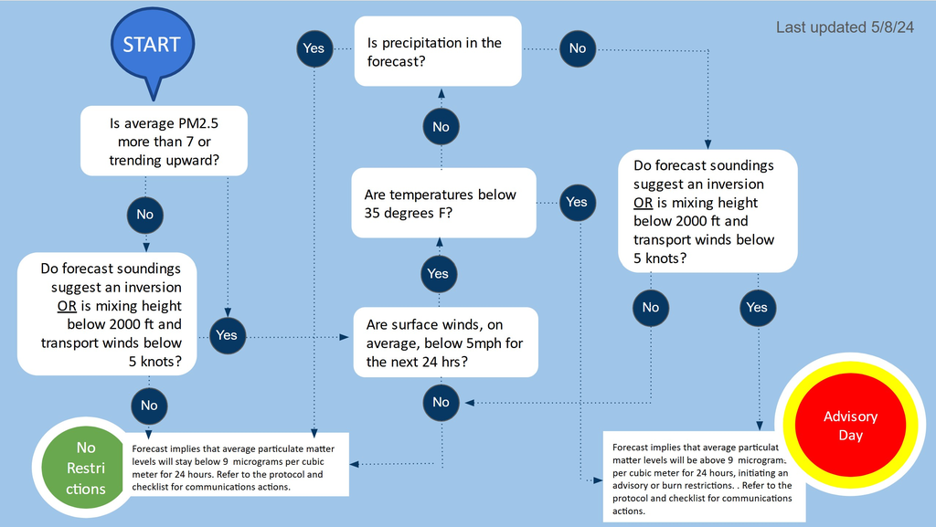

# Data

PM2.5 Table

| Date | Pollutant | 18:00:00 | 19:00:00 | 20:00:00 | 21:00:00 | 22:00:00 | 23:00:00 | 00:00:00 | 01:00:00 | 02:00:00 | 03:00:00 | 04:00:00 | 05:00:00 | 06:00:00 | 07:00:00 | 08:00:00 | 09:00:00 | 10:00:00 | 11:00:00 | 12:00:00 | 13:00:00 | 14:00:00 | 15:00:00 | 16:00:00 | 17:00:00 | ...26 | Parameter | Unit | RawConcentration | … |
| --- | --- | --- | --- | --- | --- | --- | --- | --- | --- | --- | --- | --- | --- | --- | --- | --- | --- | --- | --- | --- | --- | --- | --- | --- | --- | --- | --- | --- | --- | --- |
| 2026-10-22 | PM2.5 |  |  |  |  |  |  | 12.6 | 13.5 | 13.2 | 12.9 | 11.9 | 11.1 | 11.1 |  |  |  |  |  |  |  |  |  |  |  |  |  |  |  | … |
| 2026-10-21 | PM2.5 | 12.3 | 14.6 | 16.9 | 14.2 | 11.6 | 11.4 | 8.6 | 9.8 | 9.4 | 9.8 | 9.9 | 10.3 | 10.1 | 10.8 | 11 | 10.1 | 9.6 | 9.9 | 9.8 | 8.4 | 7.7 | 7.7 | 8.2 | 8.8 |  |  |  |  | … |

Ozone Table

| Date | Pollutant | 18:00:00 | 19:00:00 | 20:00:00 | 21:00:00 | 22:00:00 | 23:00:00 | 00:00:00 | 01:00:00 | 02:00:00 | 03:00:00 | 04:00:00 | 05:00:00 | 06:00:00 | 07:00:00 | 08:00:00 | 09:00:00 | 10:00:00 | 11:00:00 | 12:00:00 | 13:00:00 | 14:00:00 | 15:00:00 | 16:00:00 | 17:00:00 |
| --- | --- | --- | --- | --- | --- | --- | --- | --- | --- | --- | --- | --- | --- | --- | --- | --- | --- | --- | --- | --- | --- | --- | --- | --- | --- |

Protocol Data Sources:

- [WS Checklist](https://docs.google.com/document/d/1g3VP8Dcw3n0fuAT_0DBjJpdB4E96X0VYV2EPuSS-FSs/edit?tab=t.0#heading=h.i5yaswgf2k4s)
- [OR DEQ AQ Monitoring](https://aqi.oregon.gov/)
- [NOAA Weather Forecast](https://forecast.weather.gov/MapClick.php?lat=45.482920300000046&lon=-122.58685239999994#.W7OU-tNKi71)
- [NCAR Soundings](https://weather.rap.ucar.edu/upper/displayUpper.php?img=KSLE.png&endDate=-1&endTime=-1&duration=0)
- [PacNW Soundings](https://a.atmos.washington.edu/mm5rt/rt/showsounding_d2.cgi?initmodel=GFS&yyyymmddhh=current_gfs&reqhr=30&loc=kpdx&locname=Portland%2COR&latlon=45.59N,122.59W)
- [WSU Airpact](https://airpact.wsu.edu/map.html)

Additional Data:

- [Canada Smoke Forecast](https://www.weather.gc.ca/firework/index_e.html)
- [NOAA HRRR Smoke](https://apps.gsl.noaa.gov/smoke/)
- [BlueSky Smoke](https://tools.airfire.org/websky/v2/#status)
- [Canada Forecast](https://weather.gc.ca/)
- [IWFAQRP](https://outlooks.airfire.org/outlook?)
- [AirNow](https://fire.airnow.gov/#8.12/45.205/-121.949)
- [PurpleAir](https://map.purpleair.com/air-quality-standards-brazilian-pm25?opt=%2F1%2Fi%2Flp%2Fa10%2Fp604800%2FcC5#10.29/45.5355/-122.706)
- [DEQ AQ Advisory](https://experience.arcgis.com/experience/bff67fd99df247bf8ae7435dbfdc31df/)
- [Fire Dashboard](https://experience.arcgis.com/experience/6329d5e4e13748b9b9f7f33f06a3c376/)
- [NOAA/NWS AQ Forecast](https://airquality.weather.gov/?element=ozone01_bc&mapcenter=-100.52%2C39.92&mapzoom=5.079715935041019&subregion=CONUS&region=CONUS)
- [MODIS](https://ge.ssec.wisc.edu/modis-today/)
- [NOAA GOES](https://www.star.nesdis.noaa.gov/GOES/sector_band.php?sat=G17&sector=pnw&band=GEOCOLOR&length=12)
- [PDX Fire](https://x.com/PDXFire)

Updated: October 22, 2026 at 07:17 AM PDT